# Nadeem Bishtawi Assignment 8

### Importing Libraries and Early Data Exploration

```python
#Reading the training images from the path and labelling them into the given categories
import numpy as np
import pandas as pd
import matplotlib.pyplot as plt
import cv2
import os
import seaborn as sns # for data visualization
import tensorflow as tf
import keras
from tensorflow.keras.models import Sequential #sequential api for sequential model
from tensorflow.keras.layers import Dense, Dropout, Flatten #importing different layers
from tensorflow.keras.layers import Conv2D, MaxPooling2D, BatchNormalization, Activation, Input, LeakyReLU,Activation
from tensorflow.keras import backend as K
from tensorflow.keras.utils import to_categorical #to perform one-hot encoding
from tensorflow.keras.layers import Dense, Dropout, Flatten, Conv2D, MaxPool2D
from tensorflow.keras.optimizers import RMSprop,Adam #optimiers for optimizing the model
from tensorflow.keras.callbacks import EarlyStopping  #regularization method to prevent the overfitting
from tensorflow.keras.callbacks import ModelCheckpoint
from tensorflow.keras.models import Sequential, Model
from tensorflow.keras import losses, optimizers
from sklearn.model_selection import train_test_split
from tensorflow.keras.callbacks import EarlyStopping,ModelCheckpoint
from sklearn.metrics import accuracy_score, confusion_matrix
from sklearn import preprocessing
from sklearn.metrics import precision_recall_fscore_support
from sklearn.metrics import accuracy_score, confusion_matrix
```

```python
from google.colab import drive
drive.mount('/content/drive')
```

```python
images = np.load('/content/drive/My Drive/AIML/Project 8/images.npy')
data = pd.read_csv('/content/drive/My Drive/AIML/Project 8/Labels.csv')
df = data.copy()
```

```python
df.shape
```

```
(4750, 1)
```

- 4750 images in the data

```python
df.value_counts()
```

```
Label
Loose Silky-bent             654
Common Chickweed             611
Scentless Mayweed            516
Small-flowered Cranesbill    496
Fat Hen                      475
Charlock                     390
Sugar beet                   385
Cleavers                     287
Black-grass                  263
Shepherds Purse              231
Common wheat                 221
Maize                        221
dtype: int64
```

- 3 highest classes of images are Loose Silky-bent, Common Chickweed and Scentless Mayweed

### EDA

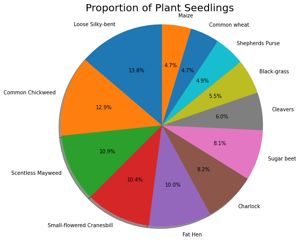

```python
labels = df['Label'].value_counts().index.tolist()
fig1, ax1 = plt.subplots(figsize=(10, 8))
ax1.pie(data = df, x= df.value_counts(), labels=labels, autopct='%1.1f%%',
        shadow=True, startangle=90)
ax1.axis('equal')
plt.title("Proportion of Plant Seedlings ", size = 20)
plt.show()
```

- reinforcing top 3 and their percentages

```python
df.head()
```

|  | Label |
| --- | --- |
| 0 | Small-flowered Cranesbill |
| 1 | Small-flowered Cranesbill |
| 2 | Small-flowered Cranesbill |
| 3 | Small-flowered Cranesbill |
| 4 | Small-flowered Cranesbill |

- peak into the data

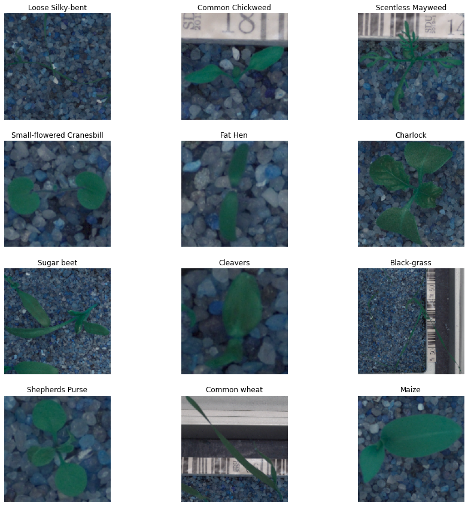

```python
fig = plt.figure(figsize = (15,15))
i=0
for label in labels:
  index = df[df['Label']==label].first_valid_index();
  ax = fig.add_subplot(4, 3, i+1);
  plt.imshow(images[index], cmap='Greys_r');
  plt.title(label);
  plt.axis('off');
  i=i+1;
plt.show();
```

- First image in the data with each classification
- Common wheat and black greass have sticks in the shape/colour of barcodes could affect CNN gradients

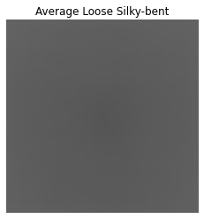

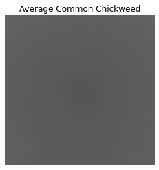

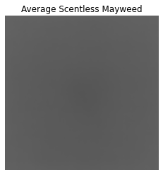

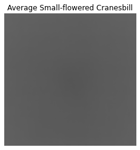

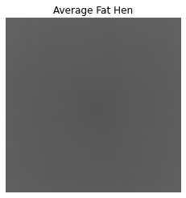

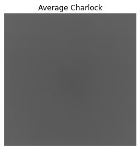

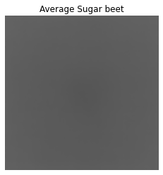

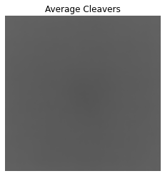

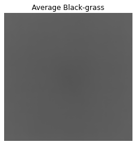

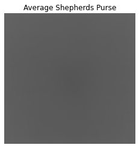

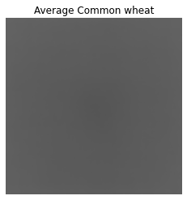

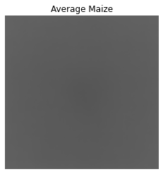

```python
def find_mean_img(full_mat, title):
    # calculate the average
    mean_img = np.mean(full_mat, axis = 0)
    # reshape it back to a matrix
    mean_img = mean_img.reshape((128,128))
    plt.imshow(mean_img, vmin=0, vmax=255, cmap='Greys_r')
    plt.title(f'Average {title}')
    plt.axis('off')
    plt.show()
    return mean_img

CATEGORIES = labels
Loose_Silky_bent_data=[]
Common_Chickweed_data=[]
Scentless_Mayweed_data=[]
Small_flowered_Cranesbill_data=[]
FatHen_data=[]
Charlock_data=[]
Sugarbeet_data=[]
Cleavers_data=[]
Black_grass_data=[]
Shepherds_Purse_data=[]
Commonwheat_data=[]
Maize_data=[]

for cat in CATEGORIES:
        for img in images:
                gray_img = cv2.cvtColor(img, cv2.COLOR_BGR2GRAY)   # Converting image to greyscale to reduce the complexity and computation
                new_array = cv2.resize(gray_img, (128, 128))
                if cat==CATEGORIES[0]:
                      Loose_Silky_bent_data.append([new_array])
                if cat==CATEGORIES[1]:
                      Common_Chickweed_data.append([new_array])
                if cat==CATEGORIES[2]:
                      Scentless_Mayweed_data.append([new_array])
                if cat==CATEGORIES[3]:
                      Small_flowered_Cranesbill_data.append([new_array])
                if cat==CATEGORIES[4]:
                      FatHen_data.append([new_array])
                if cat==CATEGORIES[5]:
                      Charlock_data.append([new_array])
                if cat==CATEGORIES[6]:
                      Sugarbeet_data.append([new_array])
                if cat==CATEGORIES[7]:
                      Cleavers_data.append([new_array])
                if cat==CATEGORIES[8]:
                      Black_grass_data.append([new_array])
                if cat==CATEGORIES[9]:
                      Shepherds_Purse_data.append([new_array])
                if cat==CATEGORIES[10]:
                      Commonwheat_data.append([new_array])
                if cat==CATEGORIES[11]:
                      Maize_data.append([new_array])



Loose_Silky_bent_mean=find_mean_img(np.array(Loose_Silky_bent_data),'Loose Silky-bent')
Common_Chickweed_mean=find_mean_img(np.array(Common_Chickweed_data),'Common Chickweed')
Scentless_Mayweed_mean=find_mean_img(np.array(Scentless_Mayweed_data),'Scentless Mayweed')
Small_flowered_Cranesbill_mean=find_mean_img(np.array(Small_flowered_Cranesbill_data),'Small-flowered Cranesbill')
FatHen_mean=find_mean_img(np.array(FatHen_data),'Fat Hen')
Charlock_mean=find_mean_img(np.array(Charlock_data),'Charlock')
Sugarbeet_mean=find_mean_img(np.array(Sugarbeet_data),'Sugar beet')
Cleavers_mean=find_mean_img(np.array(Cleavers_data),'Cleavers')
Black_grass_mean=find_mean_img(np.array(Black_grass_data),'Black-grass')
Shepherds_Purse_mean=find_mean_img(np.array(Shepherds_Purse_data),'Shepherds Purse')
Common_wheat_mean=find_mean_img(np.array(Commonwheat_data),'Common wheat')
Maize_mean=find_mean_img(np.array(Maize_data),'Maize')
```

### Grayscale and Gaussian Blurring Preprocessing

```python
for img in images:
  gray_img = cv2.cvtColor(img, cv2.COLOR_BGR2GRAY)   # Converting image to greyscale to reduce the complexity and computation
  images_grayscale = cv2.resize(gray_img, (28, 28))
```

- Turning images into grayscale

```python
images_blur_scale = np.empty((4750,28,28))
```

```python
for idx, img in enumerate(images_grayscale):
  images_blur_scale[idx] = cv2.GaussianBlur(img, (5, 5), 0)
```

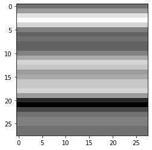

```python
plt.imshow(images_blur_scale[1], cmap='gray')
```

### Train Test Split

```python
x = np.array(images_blur_scale)
y = df["Label"]
```

```python
X_train, X_test, y_train, y_test = train_test_split(x, y, test_size=0.3, random_state=0)
```

```python
X_train = X_train.reshape(-1,28,28,1)
X_test = X_test.reshape(-1,28,28,1)
X_train = X_train /255
X_test = X_test /255
```

- Normalization of X calues

```python
lb = preprocessing.LabelBinarizer()
y_train = lb.fit_transform(y_train)
y_test = lb.fit_transform(y_test)
```

- Using alternative encoding for y variable

```python
print(X_train.shape)
print(X_test.shape)
print(y_train.shape)
print(y_test.shape)
```

[output not shown]

- Train and test shapes for X and Y variables

### Model Building - Model 1

```python
model = Sequential()
model.add(Conv2D(filters=64, kernel_size=3, activation="relu", input_shape=(28, 28, 1)))
model.add(Conv2D(filters=64, kernel_size=3, activation="relu"))
model.add(Flatten())
model.add(Dense(128, activation="relu"))
model.add(Dense(12, activation="softmax"))
```

```python
# Compile the model
model.compile(loss="categorical_crossentropy", metrics=["accuracy"], optimizer="adam")

# Fit the model
history = model.fit( x=X_train, y=y_train, batch_size=32, epochs=10, validation_split = 0.3)
```

```
dict_keys(['loss', 'accuracy', 'val_loss', 'val_accuracy'])
```

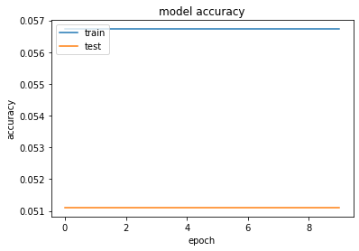

```python
print(history.history.keys())
# summarize history for accuracy
plt.plot(history.history['accuracy'])
plt.plot(history.history['val_accuracy'])
plt.title('model accuracy')
plt.ylabel('accuracy')
plt.xlabel('epoch')
plt.legend(['train', 'test'], loc='upper left')
plt.show()
```

- no change in model accuracy through epochs, we will try improving with early stops and dropout to fix any overfitting

```python
model.evaluate(X_test,y_test)
```

```
[nan, 0.05614035204052925]
```

### Model Building - Model 2

```python
es = EarlyStopping(monitor='val_loss', mode='min', verbose=1, patience=20)
mc = ModelCheckpoint('best_model.h5', monitor='val_accuracy', mode='max', verbose=1, save_best_only=True)
model2 = Sequential()
#
model2.add(Conv2D(filters=64, kernel_size=3, activation="relu", input_shape=(28, 28, 1)))

model2.add(MaxPool2D(pool_size=(2,2)))
model2.add(Dropout(0.25))

model2.add(Conv2D(filters=64, kernel_size=3, activation="relu"))

model2.add(MaxPool2D(pool_size=(2,2), strides=(2,2)))
model2.add(Dropout(0.25))

model2.add(Flatten())
model2.add(Dense(12, activation = "softmax"))

model2.compile(optimizer = "adam" , loss = "categorical_crossentropy", metrics=["accuracy"])
history_model_ln2 = model2.fit(X_train, y_train, epochs=10,batch_size=32,validation_split=0.30,callbacks=[es, mc],use_multiprocessing=True)#number of samples per gradient update for training
```

```
Epoch 00001: val_accuracy improved from -inf to 0.14228, saving model to best_model.h5
Epoch 00002: val_accuracy did not improve from 0.14228
Epoch 00003: val_accuracy did not improve from 0.14228
Epoch 00004: val_accuracy did not improve from 0.14228
Epoch 00005: val_accuracy did not improve from 0.14228
Epoch 00006: val_accuracy did not improve from 0.14228
Epoch 00007: val_accuracy did not improve from 0.14228
Epoch 00008: val_accuracy did not improve from 0.14228
Epoch 00009: val_accuracy did not improve from 0.14228
Epoch 00010: val_accuracy did not improve from 0.14228
```

```
dict_keys(['loss', 'accuracy', 'val_loss', 'val_accuracy'])
```

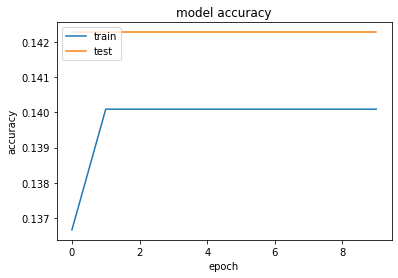

```python
print(history_model_ln2.history.keys())
# summarize history for accuracy
plt.plot(history_model_ln2.history['accuracy'])
plt.plot(history_model_ln2.history['val_accuracy'])
plt.title('model accuracy')
plt.ylabel('accuracy')
plt.xlabel('epoch')
plt.legend(['train', 'test'], loc='upper left')
plt.show()
```

- Model improved through first epoch then remained at a constant accuracy throughout the rest

```python
model2.evaluate(X_test,y_test)
```

```
[2.4278197288513184, 0.1305263191461563]
```

```python
rounded_labels=np.argmax(y_test, axis=1)
rounded_labels[1]
```

removing some encoding to be able to use y test in prediction

```python
# Test Prediction
y_test_pred_ln1 = model.predict(X_test)
y_test_pred_classes_ln1 = np.argmax(y_test_pred_ln1, axis=1)
y_test_pred_prob_ln1 = np.max(y_test_pred_ln1, axis=1)
```

```python
accuracy_score(np.array(rounded_labels), y_test_pred_classes_ln1)
```

```
0.056140350877192984
```

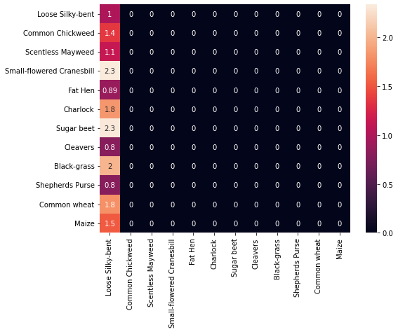

```python
cf_matrix = confusion_matrix(np.array(rounded_labels), y_test_pred_classes_ln1)

# Confusion matrix normalized per category true value
cf_matrix_n1 = cf_matrix/np.sum(cf_matrix, axis=1)
plt.figure(figsize=(8,6))
sns.heatmap(cf_matrix_n1, xticklabels=CATEGORIES, yticklabels=CATEGORIES, annot=True)
```

```python
p=precision_recall_fscore_support(np.array(rounded_labels), y_test_pred_classes_ln1, average=None,labels=list(np.unique(rounded_labels)))

print(" Precision is {}\n Recall is {} \n f_beta Score is {}".format(p[0],p[1],p[2]))
```

```
 Precision is [0.05614035 0.         0.         0.         0.         0.
 0.         0.         0.         0.         0.         0.        ]
 Recall is [1. 0. 0. 0. 0. 0. 0. 0. 0. 0. 0. 0.]
 f_beta Score is [0.10631229 0.         0.         0.         0.         0.
 0.         0.         0.         0.         0.         0.        ]
```

- Model only seemed to work with Loose Silky-bent. None of the other categories have accurate perdictions. Model is not working properly.

```python
# Test Prediction
y_test_pred_ln2 = model2.predict(X_test)
y_test_pred_classes_ln2 = np.argmax(y_test_pred_ln2, axis=1)
y_test_pred_prob_ln2 = np.max(y_test_pred_ln2, axis=1)
```

```python
# Test Accuracy
accuracy_score(np.array(rounded_labels), y_test_pred_classes_ln2)
```

```
0.13052631578947368
```

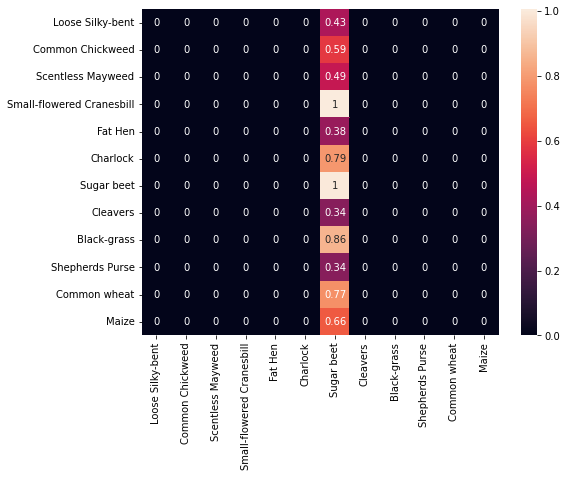

```python
cf_matrix = confusion_matrix(np.array(rounded_labels), y_test_pred_classes_ln2)

# Confusion matrix normalized per category true value
cf_matrix_n1 = cf_matrix/np.sum(cf_matrix, axis=1)
plt.figure(figsize=(8,6))
sns.heatmap(cf_matrix_n1, xticklabels=CATEGORIES, yticklabels=CATEGORIES, annot=True)
```

```python
p=precision_recall_fscore_support(np.array(rounded_labels), y_test_pred_classes_ln2, average=None,labels=list(np.unique(rounded_labels)))

print(" Precision is {}\n Recall is {} \n f_beta Score is {}".format(p[0],p[1],p[2]))
```

```
 Precision is [0.         0.         0.         0.         0.         0.
 0.13052632 0.         0.         0.         0.         0.        ]
 Recall is [0. 0. 0. 0. 0. 0. 1. 0. 0. 0. 0. 0.]
 f_beta Score is [0.         0.         0.         0.         0.         0.
 0.23091248 0.         0.         0.         0.         0.        ]
```

- Model only seemed to work with Sugar beet. None of the other categories have accurate perdictions. Model is not working properly. Accuracy is higher than model 1

### Conclusions

- Neither model worked properly. This may be due to errors in preprocessing the data or that the models do not mesh well with the data
- Models could be improved with more convolution and pool layers.
- Once a working model is applied more analysis can be done on raising recall and f1 scores of data, this was not explored here due to the models not working properly.